# Supervised Learning - Foundations: ReCell

*Marks: 60*

## Context

Buying and selling used phones and tablets used to be something that happened on a handful of online marketplace sites. But the used and refurbished device market has grown considerably over the past decade, and a new IDC (International Data Corporation) forecast predicts that the used phone market would be worth \$52.7bn by 2023 with a compound annual growth rate (CAGR) of 13.6% from 2018 to 2023. This growth can be attributed to an uptick in demand for used phones and tablets that offer considerable savings compared with new models.

Refurbished and used devices continue to provide cost-effective alternatives to both consumers and businesses that are looking to save money when purchasing one. There are plenty of other benefits associated with the used device market. Used and refurbished devices can be sold with warranties and can also be insured with proof of purchase. Third-party vendors/platforms, such as Verizon, Amazon, etc., provide attractive offers to customers for refurbished devices. Maximizing the longevity of devices through second-hand trade also reduces their environmental impact and helps in recycling and reducing waste. The impact of the COVID-19 outbreak may further boost this segment as consumers cut back on discretionary spending and buy phones and tablets only for immediate needs.

## Objective

The rising potential of this comparatively under-the-radar market fuels the need for an ML-based solution to develop a dynamic pricing strategy for used and refurbished devices. ReCell, a startup aiming to tap the potential in this market, has hired you as a data scientist. They want you to analyze the data provided and build a linear regression model to predict the price of a used phone/tablet and identify factors that significantly influence it.

## Data Description

The data contains the different attributes of used/refurbished phones and tablets. The detailed data dictionary is given below.

**Data Dictionary**

- brand_name: Name of manufacturing brand
- os: OS on which the device runs
- screen_size: Size of the screen in cm
- 4g: Whether 4G is available or not
- 5g: Whether 5G is available or not
- main_camera_mp: Resolution of the rear camera in megapixels
- selfie_camera_mp: Resolution of the front camera in megapixels
- int_memory: Amount of internal memory (ROM) in GB
- ram: Amount of RAM in GB
- battery: Energy capacity of the device battery in mAh
- weight: Weight of the device in grams
- release_year: Year when the device model was released
- days_used: Number of days the used/refurbished device has been used
- new_price: Price of a new device of the same model in euros
- used_price: Price of the used/refurbished device in euros

## Importing necessary libraries and data

```python
# Libraries to help with reading and manipulating data
import pandas as pd
import numpy as np
import matplotlib.pyplot as plt
import seaborn as sns
from sklearn.model_selection import train_test_split
from sklearn.linear_model import LinearRegression
from sklearn.metrics import mean_absolute_error, mean_squared_error, r2_score
import statsmodels.api as sm
from statsmodels.stats.outliers_influence import variance_inflation_factor
```

## Data Overview

- Observations
- Sanity checks

```python
df = pd.read_csv('used_device_data.csv')
```

```python
print(f"There are {df.shape[0]} rows and {df.shape[1]} columns")
```

```
There are 3454 rows and 15 columns
```

```python
df.sample(10, random_state=2)
```

|  | brand_name | os | screen_size | 4g | 5g | main_camera_mp | selfie_camera_mp | int_memory | ram | battery | weight | release_year | days_used | new_price | used_price |
| --- | --- | --- | --- | --- | --- | --- | --- | --- | --- | --- | --- | --- | --- | --- | --- |
| 1207 | HTC | Android | 12.700 | no | no | 8.000 | 5.000 | 32.000 | 4.000 | 2100.000 | 160.000 | 2014 | 1044 | 190.050 | 70.700 |
| 143 | Samsung | Android | 20.320 | yes | no | 5.000 | 2.000 | 16.000 | 1.500 | 4200.000 | 313.000 | 2015 | 909 | 210.230 | 75.650 |
| 3202 | Huawei | Android | 16.690 | yes | yes | 10.500 | 16.000 | 128.000 | 8.000 | 4000.000 | 178.000 | 2020 | 221 | 469.870 | 128.570 |
| 1127 | Honor | Android | 10.290 | no | no | 8.000 | 2.000 | 32.000 | 4.000 | 1730.000 | 159.000 | 2015 | 894 | 69.980 | 48.570 |
| 2926 | Xiaomi | Android | 14.830 | yes | no | 13.000 | 8.000 | 64.000 | 4.000 | 3000.000 | 150.000 | 2018 | 446 | 169.300 | 105.800 |
| 1726 | LG | Android | 7.670 | no | no | 2.000 | 1.300 | 16.000 | 4.000 | 1540.000 | 140.450 | 2014 | 952 | 61.350 | 29.490 |
| 62 | Infinix | Android | 15.390 | yes | no | nan | 16.000 | 32.000 | 3.000 | 4000.000 | 178.000 | 2019 | 316 | 99.700 | 95.130 |
| 3273 | Sony | Android | 15.370 | yes | yes | nan | 8.000 | 256.000 | 8.000 | 4000.000 | 181.400 | 2020 | 236 | 934.150 | 240.670 |
| 1411 | Others | Others | 19.940 | no | no | 5.000 | 2.000 | 32.000 | 4.000 | 4450.000 | 384.000 | 2014 | 767 | 170.810 | 78.890 |
| 551 | Alcatel | Android | 10.290 | no | no | 5.000 | 0.300 | 16.000 | 4.000 | 1800.000 | 157.000 | 2013 | 921 | 99.850 | 51.290 |

```python
df.duplicated().sum()
```

```
0
```

```python
df.info()
```

```
<class 'pandas.core.frame.DataFrame'>
RangeIndex: 3454 entries, 0 to 3453
Data columns (total 15 columns):
 #   Column            Non-Null Count  Dtype
---  ------            --------------  -----
 0   brand_name        3454 non-null   object
 1   os                3454 non-null   object
 2   screen_size       3454 non-null   float64
 3   4g                3454 non-null   object
 4   5g                3454 non-null   object
 5   main_camera_mp    3275 non-null   float64
 6   selfie_camera_mp  3452 non-null   float64
 7   int_memory        3450 non-null   float64
 8   ram               3450 non-null   float64
 9   battery           3448 non-null   float64
 10  weight            3447 non-null   float64
 11  release_year      3454 non-null   int64
 12  days_used         3454 non-null   int64
 13  new_price         3454 non-null   float64
 14  used_price        3454 non-null   float64
dtypes: float64(9), int64(2), object(4)
memory usage: 404.9+ KB
```

```python
df.isnull().sum()
```

```
brand_name            0
os                    0
screen_size           0
4g                    0
5g                    0
main_camera_mp      179
selfie_camera_mp      2
int_memory            4
ram                   4
battery               6
weight                7
release_year          0
days_used             0
new_price             0
used_price            0
dtype: int64
```

## Exploratory Data Analysis (EDA)

- EDA is an important part of any project involving data.
- It is important to investigate and understand the data better before building a model with it.
- A few questions have been mentioned below which will help you approach the analysis in the right manner and generate insights from the data.
- A thorough analysis of the data, in addition to the questions mentioned below, should be done.

**Questions**:

1. What does the distribution of used device prices look like?
2. What percentage of the used device market is dominated by Android devices?
3. The amount of RAM is important for the smooth functioning of a device. How does the amount of RAM vary with the brand?
4. A large battery often increases a device's weight, making it feel uncomfortable in the hands. How does the weight vary for phones and tablets offering large batteries (more than 4500 mAh)?
5. Bigger screens are desirable for entertainment purposes as they offer a better viewing experience. How many phones and tablets are available across different brands with a screen size larger than 6 inches?
6. Budget devices nowadays offer great selfie cameras, allowing us to capture our favorite moments with loved ones. What is the distribution of budget devices offering greater than 8MP selfie cameras across brands?
7. Which attributes are highly correlated with the price of a used device?

```python
df.describe(include="all").T
```

|  | count | unique | top | freq | mean | std | min | 25% | 50% | 75% | max |
| --- | --- | --- | --- | --- | --- | --- | --- | --- | --- | --- | --- |
| brand_name | 3454 | 34 | Others | 502 | NaN | NaN | NaN | NaN | NaN | NaN | NaN |
| os | 3454 | 4 | Android | 3214 | NaN | NaN | NaN | NaN | NaN | NaN | NaN |
| screen_size | 3454.000 | NaN | NaN | NaN | 13.713 | 3.805 | 5.080 | 12.700 | 12.830 | 15.340 | 30.710 |
| 4g | 3454 | 2 | yes | 2335 | NaN | NaN | NaN | NaN | NaN | NaN | NaN |
| 5g | 3454 | 2 | no | 3302 | NaN | NaN | NaN | NaN | NaN | NaN | NaN |
| main_camera_mp | 3275.000 | NaN | NaN | NaN | 9.460 | 4.815 | 0.080 | 5.000 | 8.000 | 13.000 | 48.000 |
| selfie_camera_mp | 3452.000 | NaN | NaN | NaN | 6.554 | 6.970 | 0.000 | 2.000 | 5.000 | 8.000 | 32.000 |
| int_memory | 3450.000 | NaN | NaN | NaN | 54.573 | 84.972 | 0.010 | 16.000 | 32.000 | 64.000 | 1024.000 |
| ram | 3450.000 | NaN | NaN | NaN | 4.036 | 1.365 | 0.020 | 4.000 | 4.000 | 4.000 | 12.000 |
| battery | 3448.000 | NaN | NaN | NaN | 3133.403 | 1299.683 | 500.000 | 2100.000 | 3000.000 | 4000.000 | 9720.000 |
| weight | 3447.000 | NaN | NaN | NaN | 182.752 | 88.413 | 69.000 | 142.000 | 160.000 | 185.000 | 855.000 |
| release_year | 3454.000 | NaN | NaN | NaN | 2015.965 | 2.298 | 2013.000 | 2014.000 | 2015.500 | 2018.000 | 2020.000 |
| days_used | 3454.000 | NaN | NaN | NaN | 674.870 | 248.580 | 91.000 | 533.500 | 690.500 | 868.750 | 1094.000 |
| new_price | 3454.000 | NaN | NaN | NaN | 237.039 | 194.303 | 18.200 | 120.343 | 189.785 | 291.115 | 2560.200 |
| used_price | 3454.000 | NaN | NaN | NaN | 92.303 | 54.702 | 4.650 | 56.483 | 81.870 | 116.245 | 749.520 |

```python
# function to plot a boxplot and a histogram along the same scale.


def histogram_boxplot(data, feature, figsize=(12, 7), kde=False, bins=None):
    """
    Boxplot and histogram combined

    data: dataframe
    feature: dataframe column
    figsize: size of figure (default (12,7))
    kde: whether to the show density curve (default False)
    bins: number of bins for histogram (default None)
    """
    f2, (ax_box2, ax_hist2) = plt.subplots(
        nrows=2,  # Number of rows of the subplot grid= 2
        sharex=True,  # x-axis will be shared among all subplots
        gridspec_kw={"height_ratios": (0.25, 0.75)},
        figsize=figsize,
    )  # creating the 2 subplots
    sns.boxplot(
        data=data, x=feature, ax=ax_box2, showmeans=True, color="violet"
    )  # boxplot will be created and a star will indicate the mean value of the column
    sns.histplot(
        data=data, x=feature, kde=kde, ax=ax_hist2, bins=bins, palette="winter"
    ) if bins else sns.histplot(
        data=data, x=feature, kde=kde, ax=ax_hist2
    )  # For histogram
    ax_hist2.axvline(
        data[feature].mean(), color="green", linestyle="--"
    )  # Add mean to the histogram
    ax_hist2.axvline(
        data[feature].median(), color="black", linestyle="-"
    )  # Add median to the histogram
```

## Answers to Questions in EDA

#### Analysis of Used Price Column

1. What does the distribution of used device prices look like?

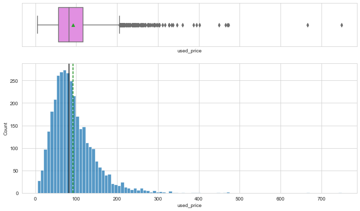

```python
histogram_boxplot(df, "used_price")
```

**Observations**

- There is a wide dispersion in the data with many outliers on the higher end
- This will be something that is good to add a log scale as we will need this for further analysis later

```python
df['used_price_log'] = np.log(df['used_price'])
```

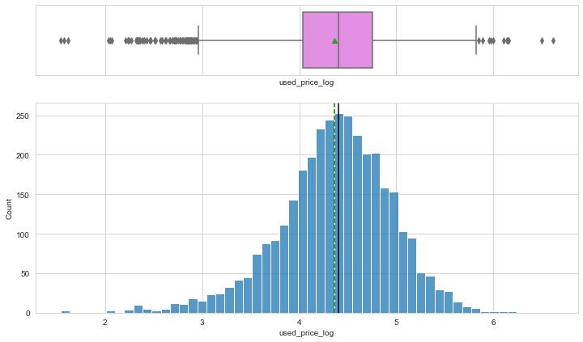

```python
histogram_boxplot(df, "used_price_log")
```

**Observations**

- With the log, the data is now in a more uniform distribution that we can use

```python
## Reworked this function to allow me to provide my own order and if not then use the default

def labeled_barplot(data, feature, perc=False, n=None, order=None):
    """
    Barplot with percentage at the top

    data: dataframe
    feature: dataframe column
    perc: whether to display percentages instead of count (default is False)
    n: displays the top n category levels (default is None, i.e., display all levels)
    """

    total = len(data[feature])  # length of the column
    count = data[feature].nunique()
    if n is None:
        plt.figure(figsize=(count + 1, 5))
    else:
        plt.figure(figsize=(n + 1, 5))

    if order is None:
        order = data[feature].value_counts().index[:n].sort_values()

    plt.xticks(rotation=90, fontsize=15)
    ax = sns.countplot(data=data, x=feature, palette="Paired", order = order)

    for p in ax.patches:
        if perc == True:
            label = "{:.1f}%".format(100 * p.get_height() / total)  # percentage of each class of the category
        else:
            label = p.get_height()  # count of each level of the category

        x = p.get_x() + p.get_width() / 2  # width of the plot
        y = p.get_height()      # height of the plot

        ax.annotate(label, (x, y), ha="center", va="center", size=12, xytext=(0, 5), textcoords="offset points")  # annotate the percentage


    plt.show()  # show the plot
```

#### Analysis of Operation Systems Column

1. What percentage of the used device market is dominated by Android devices?

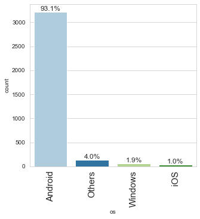

```python
labeled_barplot(df, 'os', perc = True)
```

**Observations**

- 93% of the used device market is dominated by Android

#### Analysis of Ram and Brand

1. The amount of RAM is important for the smooth functioning of a device. How does the amount of RAM vary with the brand?

```python
df['ram'].value_counts()
```

```
4.000     2815
6.000      154
8.000      130
2.000       90
0.250       83
3.000       81
1.000       34
0.020       18
12.000      18
0.030       17
0.500        9
1.500        1
Name: ram, dtype: int64
```

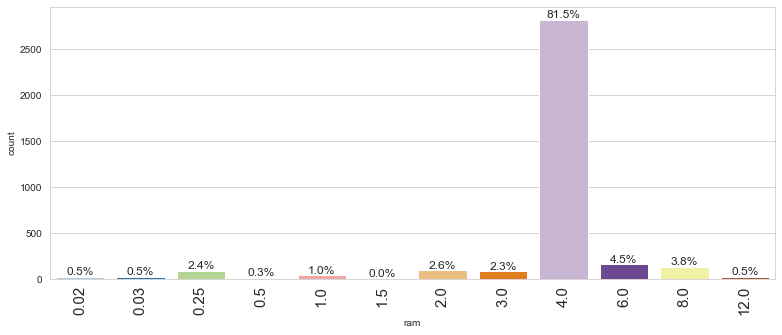

```python
labeled_barplot(df, 'ram', perc = True)
```

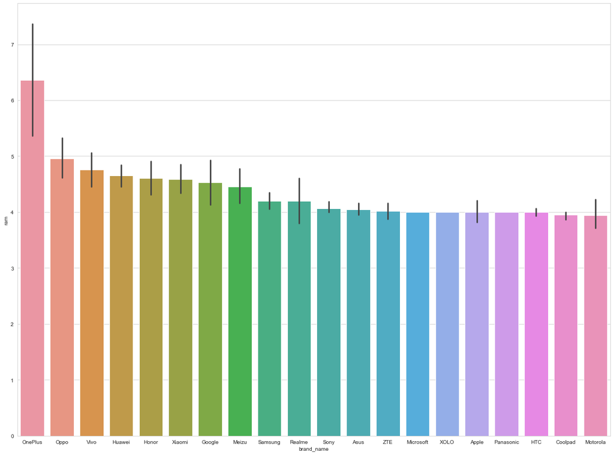

```python
plt.figure(figsize=(20,15))
sns.barplot(data = df, x = 'brand_name', y = 'ram', order = df.groupby(['brand_name'])['ram'].mean().sort_values(ascending=False).iloc[:20].index)
plt.show()
```

**Observations**

- On average OnePlus has the most RAM in their used phones by a large margin
- Oppo, Vivo, Huawei, Honor are the second through 5 highest RAM
- The most common RAM is 4
- 81% of used phones have a RAM of 4

**Analysis of Weight for Phones with Large Batteries**

1. A large battery often increases a device's weight, making it feel uncomfortable in the hands. How does the weight vary for phones and tablets offering large batteries (more than 4500 mAh)?

```python
large_batteries = df[df['battery'] > 4500]
print(f'There are {large_batteries.shape[0]} devices with a large battery')
print(f'The percentage of device of the total with large batteries is {round(large_batteries.shape[0] / df.shape[0] * 100,2)}%')
```

```
There are 341 devices with a large battery
The percentage of device of the total with large batteries is 9.87%
```

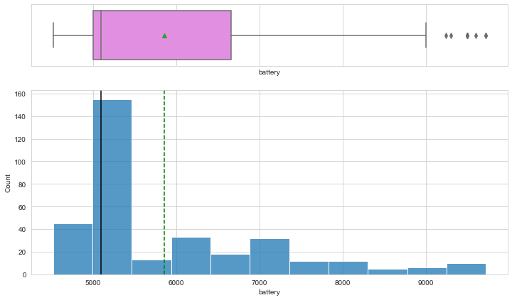

```python
histogram_boxplot(large_batteries, 'battery')
```

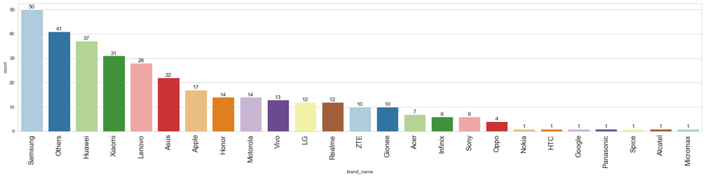

```python
labeled_barplot(large_batteries, 'brand_name', order = large_batteries.groupby('brand_name')['battery'].agg('count').sort_values(ascending=False).index)
```

**Observations**

**Analysis of Phones with Larger Screens**

1. Bigger screens are desirable for entertainment purposes as they offer a better viewing experience. How many phones and tablets are available across different brands with a screen size larger than 6 inches?

```python
# Create new data frame and add a column for screen size in inches
inches = df.copy()
inches['screen_size_inches'] = inches['screen_size'].apply(lambda x: round(x /2.54,2))
large_device = inches[inches['screen_size_inches'] > 6]
```

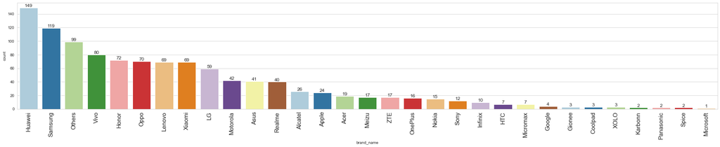

```python
labeled_barplot(large_device, 'brand_name', order = large_device.groupby('brand_name')['screen_size_inches'].agg('count').sort_values(ascending=False).index)
```

```python
print(f'There are {large_device.shape[0]} devices with large screens')
print(f'The percentage of devices with large screens is {round(large_device.shape[0] / inches.shape[0] * 100,2)}%')
```

```
There are 1099 devices with large screens
The percentage of devices with large screens is 31.82%
```

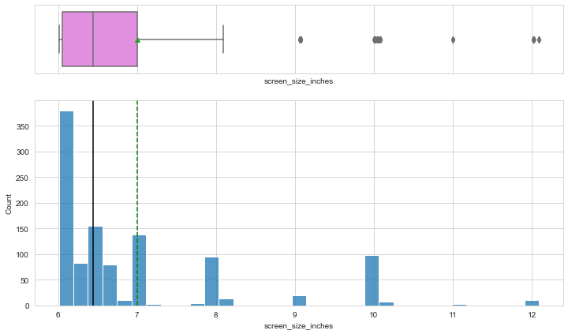

```python
histogram_boxplot(large_device, 'screen_size_inches')
```

**Observations**

- There are 1099 devices with large screens which makes up 31.82% of the total
- Huawei and Samsung make the most large devices
- There is a wide spread in the data of devices because there is a mix of Smart Phones and Tablets in the data

#### Budget Devices with Great Cameras

1. Budget devices nowadays offer great selfie cameras, allowing us to capture our favorite moments with loved ones. What is the distribution of budget devices offering greater than 8MP selfie cameras across brands?

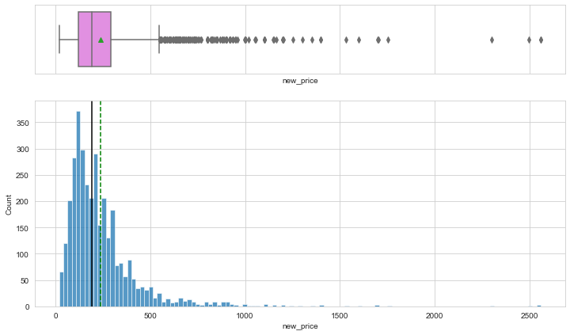

```python
histogram_boxplot(df, 'new_price')
```

```python
df['new_price'].describe()
```

```
count   3454.000
mean     237.039
std      194.303
min       18.200
25%      120.343
50%      189.785
75%      291.115
max     2560.200
Name: new_price, dtype: float64
```

```python
df['price_category'] = pd.cut(x=df['new_price'],bins=[-np.infty, 200, 400, np.infty],labels=['Budget', 'Mid', 'Premium'])
df['price_category'].value_counts()
```

```
Budget     1844
Mid        1188
Premium     422
Name: price_category, dtype: int64
```

```python
budget_good_camera = df.loc[(df['price_category'] == 'Budget') & (df['selfie_camera_mp'] > 8)]
budget_good_camera.head()
```

|  | brand_name | os | screen_size | 4g | 5g | main_camera_mp | selfie_camera_mp | int_memory | ram | battery | weight | release_year | days_used | new_price | used_price | used_price_log | price_category |
| --- | --- | --- | --- | --- | --- | --- | --- | --- | --- | --- | --- | --- | --- | --- | --- | --- | --- |
| 17 | Honor | Android | 16.740 | yes | no | 13.000 | 16.000 | 64.000 | 4.000 | 4000.000 | 206.000 | 2019 | 421 | 180.040 | 118.750 | 4.777 | Budget |
| 22 | HTC | Android | 15.290 | yes | no | 13.000 | 16.000 | 32.000 | 3.000 | 3850.000 | 170.000 | 2019 | 187 | 180.500 | 95.660 | 4.561 | Budget |
| 41 | Huawei | Android | 15.900 | yes | no | 13.000 | 32.000 | 64.000 | 6.000 | 4000.000 | 178.000 | 2019 | 206 | 199.250 | 147.900 | 4.997 | Budget |
| 48 | Huawei | Android | 16.740 | yes | no | 13.000 | 16.000 | 128.000 | 4.000 | 4000.000 | 163.500 | 2019 | 376 | 190.620 | 126.380 | 4.839 | Budget |
| 62 | Infinix | Android | 15.390 | yes | no | nan | 16.000 | 32.000 | 3.000 | 4000.000 | 178.000 | 2019 | 316 | 99.700 | 95.130 | 4.555 | Budget |

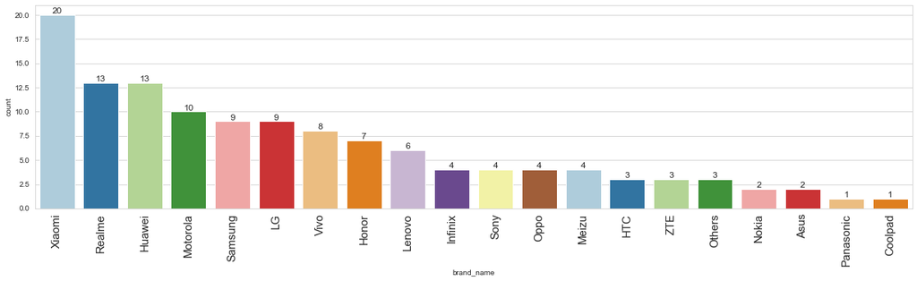

```python
labeled_barplot(budget_good_camera, 'brand_name', order = budget_good_camera.groupby('brand_name')['selfie_camera_mp'].agg('count').sort_values(ascending=False).index)
```

**Observations**

- There is a wide distribution of the prices
- Used below 200 for a budget device, between 200-400 for Mid device and above 400 for premium
- Xiaomi makes the most budget devices with large camera followed by Realme and Huawei

#### Correlation for Used Device

1. Which attributes are highly correlated with the price of a used device?

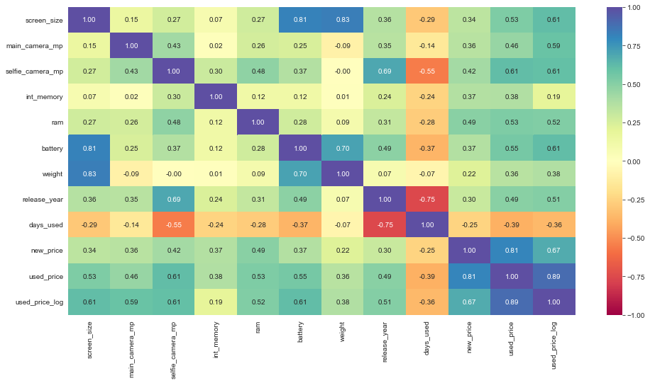

```python
plt.figure(figsize=(16, 8))
sns.heatmap(df.corr(), annot=True, vmin=-1, vmax=1, fmt=".2f", cmap="Spectral")
plt.show()
```

**Observations**

- The attributes which are most heavily correlated with the price are: new_price, selfie_camera_mp, battery, ram and screensize
- days_used is negative correlated with used_price which we would expect

## Univariate Analysis

```python
df.head()
```

|  | brand_name | os | screen_size | 4g | 5g | main_camera_mp | selfie_camera_mp | int_memory | ram | battery | weight | release_year | days_used | new_price | used_price | used_price_log | price_category |
| --- | --- | --- | --- | --- | --- | --- | --- | --- | --- | --- | --- | --- | --- | --- | --- | --- | --- |
| 0 | Honor | Android | 14.500 | yes | no | 13.000 | 5.000 | 64.000 | 3.000 | 3020.000 | 146.000 | 2020 | 127 | 111.620 | 74.260 | 4.308 | Budget |
| 1 | Honor | Android | 17.300 | yes | yes | 13.000 | 16.000 | 128.000 | 8.000 | 4300.000 | 213.000 | 2020 | 325 | 249.390 | 174.530 | 5.162 | Mid |
| 2 | Honor | Android | 16.690 | yes | yes | 13.000 | 8.000 | 128.000 | 8.000 | 4200.000 | 213.000 | 2020 | 162 | 359.470 | 165.850 | 5.111 | Mid |
| 3 | Honor | Android | 25.500 | yes | yes | 13.000 | 8.000 | 64.000 | 6.000 | 7250.000 | 480.000 | 2020 | 345 | 278.930 | 169.930 | 5.135 | Mid |
| 4 | Honor | Android | 15.320 | yes | no | 13.000 | 8.000 | 64.000 | 3.000 | 5000.000 | 185.000 | 2020 | 293 | 140.870 | 80.640 | 4.390 | Budget |

#### Analysis of Brand Name

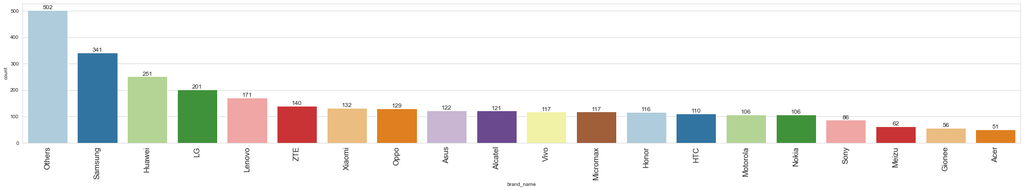

```python
labeled_barplot(df, 'brand_name', order=df.groupby(['brand_name'])['ram'].count().sort_values(ascending=False).iloc[:20].index)
```

```python
df['brand_name'].value_counts()
```

```
Others        502
Samsung       341
Huawei        251
LG            201
Lenovo        171
ZTE           140
Xiaomi        132
Oppo          129
Asus          122
Alcatel       121
Micromax      117
Vivo          117
Honor         116
HTC           110
Motorola      106
Nokia         106
Sony           86
Meizu          62
Gionee         56
Acer           51
XOLO           49
Panasonic      47
Realme         41
Apple          39
Lava           36
Celkon         33
Spice          30
Karbonn        29
OnePlus        22
Microsoft      22
BlackBerry     22
Coolpad        22
Google         15
Infinix        10
Name: brand_name, dtype: int64
```

**Observations**

- Others has a high value count which makes it tough for analysis since we do not know what brand
- Samsung, Huawei, LG have the highest count of devices

#### Analysis of OS

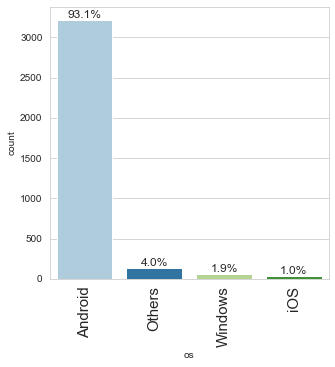

```python
labeled_barplot(df, 'os', perc=True)
```

**Observations**

- Android dominates the OS market in the devices in the dataset
- Android has 93% of the devices in the dataset

#### Analysis of Screen Size

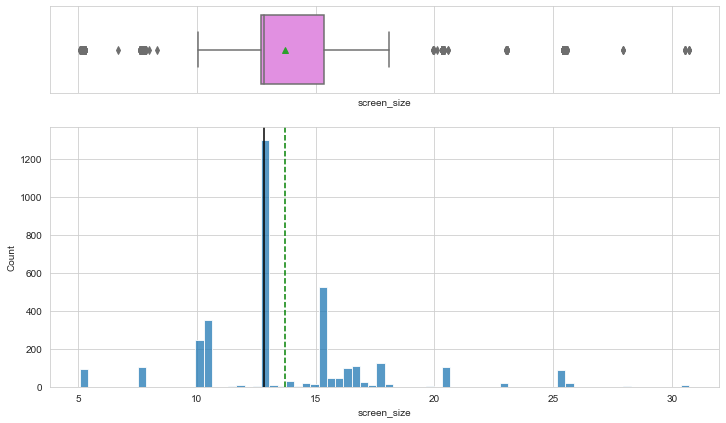

```python
histogram_boxplot(df, 'screen_size')
```

**Observations**

- The data for screen size has a wide disparity with many data points outside the whiskers of the boxplot on both directions
- Screen size is something that we could potentially look to break into categories

#### Analysis of 4G

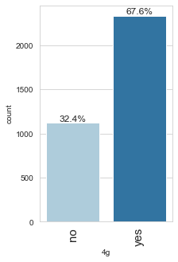

```python
labeled_barplot(df, '4g', perc = True)
```

**Observations**

- 67.6% of the phones are 4G

#### Analysis of 5G

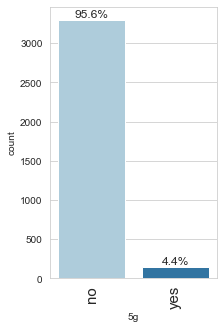

```python
labeled_barplot(df, '5g', perc = True)
```

**Obversations**

- 4.4% of phones have 5G

#### Analysis of Main Camera

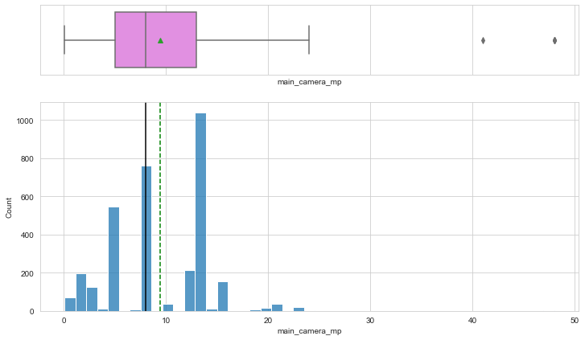

```python
histogram_boxplot(df, 'main_camera_mp')
```

**Observations**

- There are a few devices which have a large main camera
- The average of devices is just under 10 MP

#### Analysis of Selfie Camera

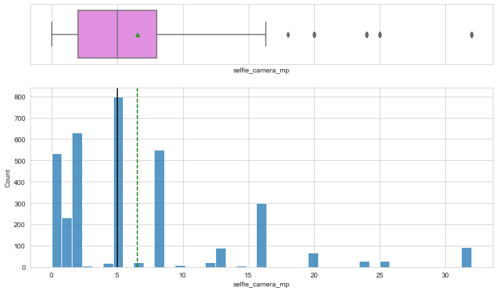

```python
histogram_boxplot(df, 'selfie_camera_mp')
```

**Obvservations**

- There is a wide distribution of devices with selfie cameras
- There are a few devices with more than 30 MP
- The median is 5 MP

#### Analysis of Memory

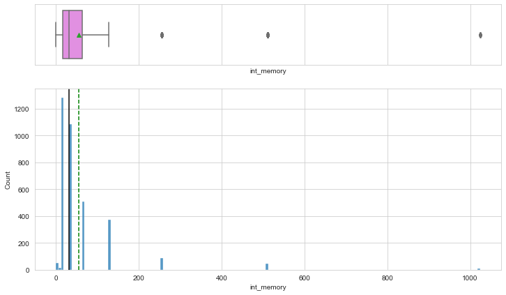

```python
histogram_boxplot(df, 'int_memory')
```

**Obversations**

- There are a few devices which have a large deal of memory, way above the rest of the data
- These large data points will skew the average higher

#### Analysis of RAM

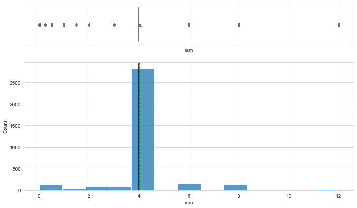

```python
histogram_boxplot(df, 'ram')
```

**Obversations**

#### Analysis of Battery

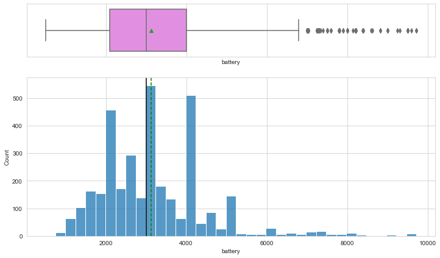

```python
histogram_boxplot(df, 'battery')
```

**Observations**

- The average battery size is around 3000
- There are some devices which have almost 10000 mAh battery
- There are many devices above the whiskers in the boxplot but none below the whiskers

#### Analysis of Weight

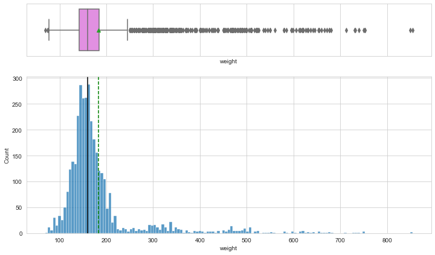

```python
histogram_boxplot(df, 'weight')
```

**Observation**

- There is a wide disperion in the data for weight with many devices on the large end
- This could be a potential field for us to use a log for better analysis

#### Analysis of Release Year

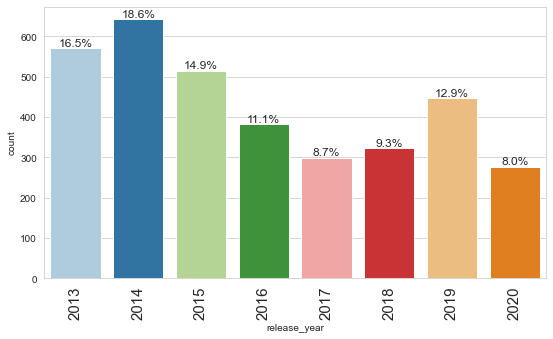

```python
labeled_barplot(df, 'release_year', perc = True)
```

**Obervations**

- No year is dominating the release year category
- 2014 is the most common year followed by 2013 and 2015

#### Analysis of Days Used

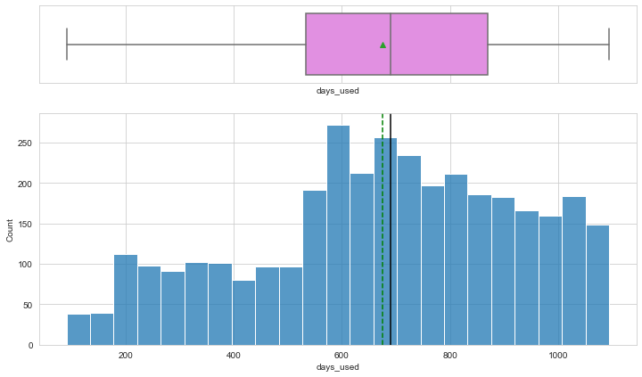

```python
histogram_boxplot(df, 'days_used')
```

**Observations**

- The data for datas used does not look to have any data points outside the whiskers
- Most data is around the average and median

#### Analysis of New Price

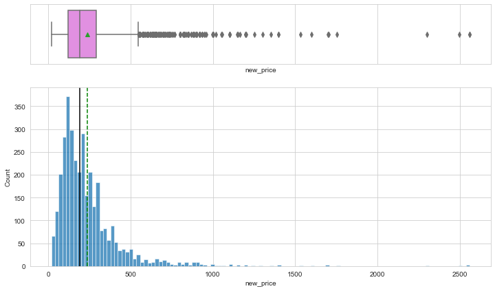

```python
histogram_boxplot(df, 'new_price')
```

**Obversations**

- Data for New Price has some devices that are much larger than the average
- This is another candidate for a using a log

#### Analysis of Used Price

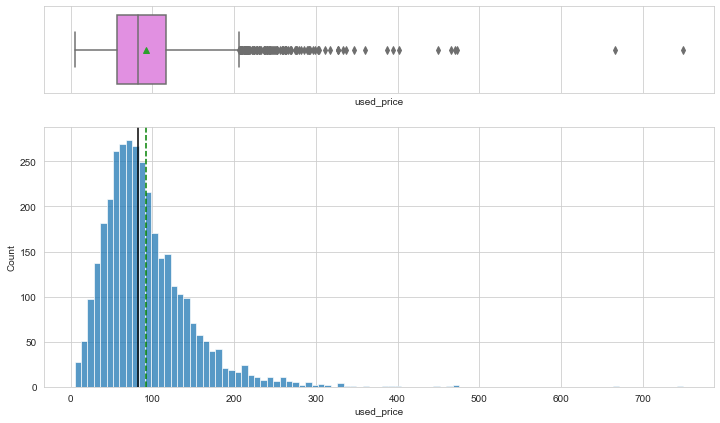

```python
histogram_boxplot(df, 'used_price')
```

**Observations**

- Similar to New Price, there is a wide dispersion of data for used price
- This is another column that we will want to create a log for

## Bivariate Analysis

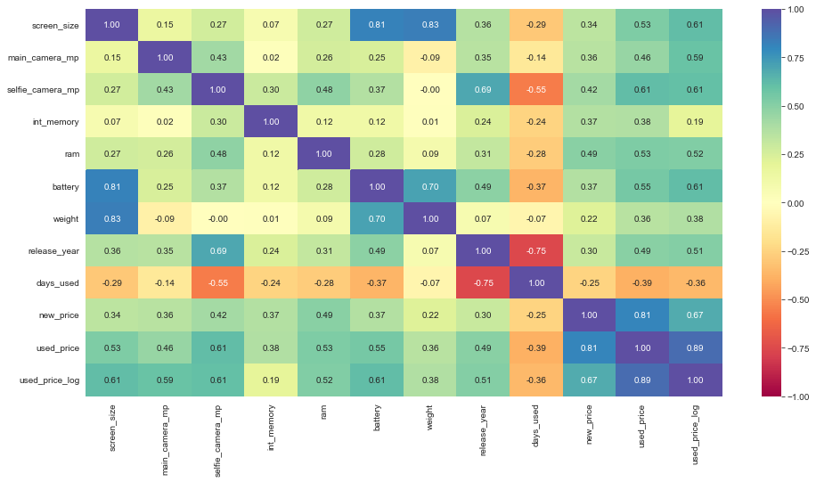

```python
plt.figure(figsize=(16, 8))
sns.heatmap(df.corr(), annot=True, vmin=-1, vmax=1, fmt=".2f", cmap="Spectral")
plt.show()
```

#### Analysis of Brand Name vs Used Price

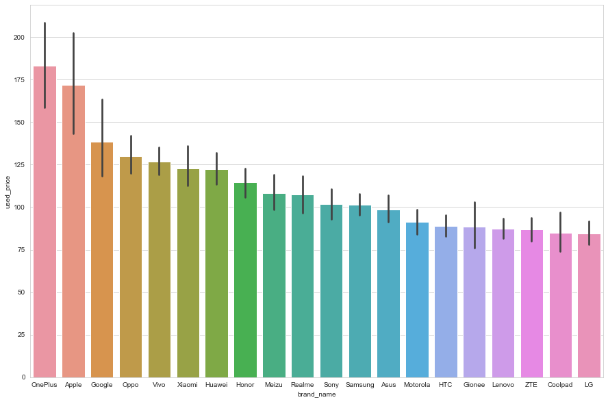

```python
plt.figure(figsize=(15,10))
sns.barplot(data = df, x = 'brand_name', y = 'used_price', order = df.groupby(['brand_name'])['used_price'].mean().sort_values(ascending=False).iloc[:20].index)
plt.show()
```

**Obvervations**

- OnePlus, Apple and Google on average have the most expensive devices by used price

#### Analysis of Brand Name vs Screen Size

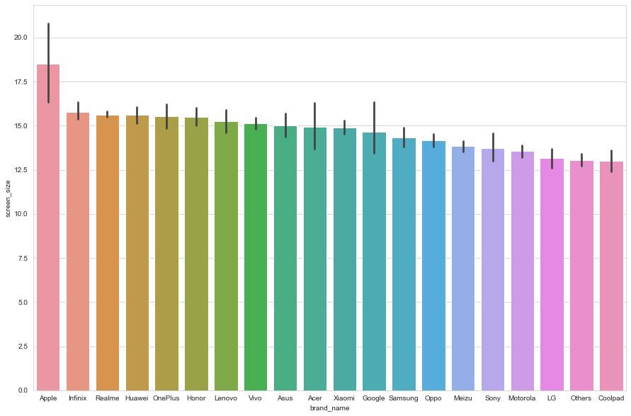

```python
plt.figure(figsize=(15,10))
sns.barplot(data = df, x = 'brand_name', y = 'screen_size', order = df.groupby(['brand_name'])['screen_size'].mean().sort_values(ascending=False).iloc[:20].index)
plt.show()
```

**Observations**

- On average Apple devices have the largest screens followed by Infinix and Realme